# STA 141A Homework 4

Li Yuan

5/6/2022

# I. Multiple linear regression: Simulated data

## Problem 1

**Run the following code to create the vectors `x1`, `x2`, and `y`.**

```r
set.seed(1)
n <- 100
x1 <- runif(n)
x2 <- runif(n,10,20)
y <- 2+2*x1+0.3*x2+rnorm(n)
```

**a. (1 pts) The last line of the code above corresponds to creating a linear model in which `y` is a function of `x1` and `x2`. Write out the form of the linear model. What are the values of the regression coefficients $\beta_0$, $\beta_1$ and $\beta_2$? What is the value of $\sigma^2$?**

The linear model is $Y=2+2X_1+0.3X_2+\epsilon$ which is `lm(y ~ x1 + x2)` in `R`.

$\beta_0=2$, $\beta_1=2$, and $\beta_2=0.3$. $\sigma^2=1$.

**b. (1 pts) Use the function `cor()` to calculate the correlation coefficient between `x1` and `x2`. Create a scatter plot using `ggplot2` displaying the relationship between the variables `x1` and `x2`. What can you say about the direction and strength of their relationship?**

```r
correlation = cor(x1, x2)
correlation
```

```
## [1] 0.01703215
```

The correlation coefficient between `x1` and `x2` is 0.0170321.

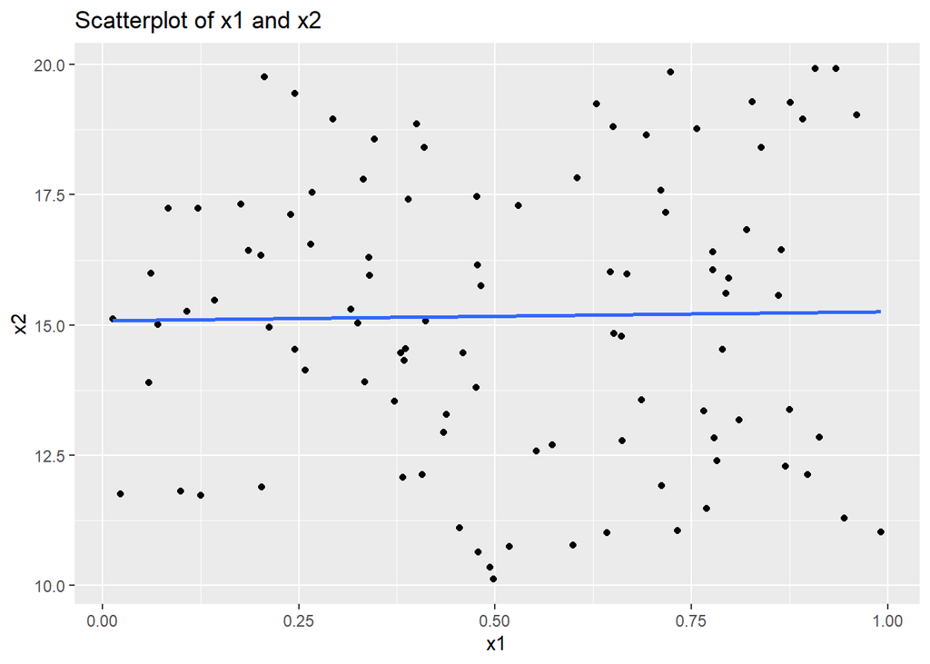

```r
x1x2 = data.frame(x1, x2)
ggplot(data = x1x2, mapping = aes(x = x1, y = x2))+
  geom_point()+
  ggtitle("Scatterplot of x1 and x2") +
  geom_smooth(method = "lm", se = FALSE)
```

According to our correlation coefficient 0.0170321 and the scatterplot, it may have not strong, positive, linear relationship.

**c. (2 pts) Fit a least squares regression to predict `y` using `x1` and `x2`. Describe the obtained results. What are the values of $\hat{\beta_0}$, $\hat{\beta_1}$ and $\hat{\beta_2}$? How do these relate to the true values of $\beta_0$, $\beta_1$ and $\beta_2$? What is the value of `s` and how does it relate to the true value of $\sigma^2$? Can you reject the null hypothesis $H_0:~\beta_1=0$? How about the null hypothesis $H_0:~\beta_2=0$?**

```r
model = lm(y ~ x1 + x2)
model
```

```
##
## Call:
## lm(formula = y ~ x1 + x2)
##
## Coefficients:
## (Intercept)           x1           x2
##      1.9763       1.9307       0.3014
```

From the above code we can know that $\hat{\beta_0}$ = 1.9762757, $\hat{\beta_1}$ = 1.9307364, and $\hat{\beta_2}$ = 0.3014356. They are estimators of $\beta_0$, $\beta_1$ and $\beta_2$.

Since $\beta_0=2$, $\beta_1=2$, and $\beta_2=0.3$, which are similar to $\hat{\beta_0}$ = 1.9762757, $\hat{\beta_1}$ = 1.9307364, and $\hat{\beta_2}$ = 0.3014356. We may say that they are relative good estimators.

```r
s = sqrt(sum((model$residuals)^2)/(n-2-1))
s
```

```
## [1] 0.9675158
```

From the code above, we can see that $s$ = 0.9675158. Since $\sigma^2$ = 1, which is similar to 0.9675158. So `s` is a relative good estimator of $\sigma^2$.

```r
summary(model)
```

```
##
## Call:
## lm(formula = y ~ x1 + x2)
##
## Residuals:
##     Min      1Q  Median      3Q     Max
## -1.8579 -0.6167 -0.1432  0.5352  2.3318
##
## Coefficients:
##             Estimate Std. Error t value Pr(>|t|)
## (Intercept)  1.97628    0.57973   3.409 0.000951 ***
## x1           1.93074    0.36345   5.312 6.89e-07 ***
## x2           0.30144    0.03578   8.425 3.33e-13 ***
## ---
## Signif. codes:  0 '***' 0.001 '**' 0.01 '*' 0.05 '.' 0.1 ' ' 1
##
## Residual standard error: 0.9675 on 97 degrees of freedom
## Multiple R-squared:  0.5095, Adjusted R-squared:  0.4994
## F-statistic: 50.38 on 2 and 97 DF,  p-value: 9.917e-16
```

Based on the results we got from above, we reject $H_0:~\beta_1=0$ and $H_0:~\beta_2=0$ since the p-values of `x1` = 6.8900468^{-7} and `x2` = 3.3279749^{-13} are too small, smaller than any p-values we usually use.

**d. (2 pts) Now fit a least squares regression to predict `y` using only `x1`. Comment on your results. What are the values of $\hat{\beta_0}$ and $\hat{\beta_1}$? How do these relate to the true values of $\beta_0$ and $\beta_1$? What is the value of `s` and how does it relate to the true value of $\sigma^2$? Can you reject the null hypothesis $H_0:~\beta_1=0$?**

```r
model = lm(y ~ x1)
model
```

```
##
## Call:
## lm(formula = y ~ x1)
##
## Coefficients:
## (Intercept)           x1
##       6.523        1.983
```

From the above code we can know that $\hat{\beta_0}$ = 6.523468 and $\hat{\beta_1}$ = 1.9828892. They just estimators of $\beta_0$ and $\beta_1$.

Obviously, $\beta_0=2$ is not similar to $\hat{\beta_0}$ = 6.523468. As a result, $\hat{\beta_0}$ is not a relative good estimator of $\beta_0$.

However, $\beta_1=2$ is similar to $\hat{\beta_1}$ = 1.9828892. As a result, $\hat{\beta_1}$ is a relative good estimator of $\beta_1$.

```r
s = sqrt(sum((model$residuals)^2)/(n-1-1))
s
```

```
## [1] 1.266699
```

From the code above, we can see that $s$ = 1.2666986. Since $\sigma^2$ = 1, which is not similar to 1.2666986. So `s` is not a relative good estimator of $\sigma^2$.

```r
summary(model)
```

```
##
## Call:
## lm(formula = y ~ x1)
##
## Residuals:
##      Min       1Q   Median       3Q      Max
## -2.48228 -0.97125 -0.03059  0.93666  2.78169
##
## Coefficients:
##             Estimate Std. Error t value Pr(>|t|)
## (Intercept)   6.5235     0.2770  23.548  < 2e-16 ***
## x1            1.9829     0.4758   4.168 6.64e-05 ***
## ---
## Signif. codes:  0 '***' 0.001 '**' 0.01 '*' 0.05 '.' 0.1 ' ' 1
##
## Residual standard error: 1.267 on 98 degrees of freedom
## Multiple R-squared:  0.1506, Adjusted R-squared:  0.1419
## F-statistic: 17.37 on 1 and 98 DF,  p-value: 6.638e-05
```

Based on the results we got from above, we reject $H_0:~\beta_1=0$ since the p-value of `x1` = 6.6379472^{-5} is too small, smaller than any p-values we usually use.

**e. (2 pts) Now fit a least squares regression to predict `y` using only `x2`. Comment on your results. What are the values of $\hat{\beta_0}$ and $\hat{\beta_2}$? How do these relate to the true values of $\beta_0$ and $\beta_2$? What is the value of `s` and does it relate to the true value of $\sigma^2$? Can you reject the null hypothesis $H_0:~\beta_2=0$?**

```r
model = lm(y ~ x2)
model
```

```
##
## Call:
## lm(formula = y ~ x2)
##
## Coefficients:
## (Intercept)           x2
##      2.9270       0.3047
```

From the above code we can know that $\hat{\beta_0}$ = 2.9269773 and $\hat{\beta_2}$ = 0.3046728. They are estimators of $\beta_0$ and $\beta_2$.

Obviously, $\beta_0=2$ is not similar to $\hat{\beta_0}$ = 2.9269773. As a result, $\hat{\beta_0}$ is not a relative good estimator of $\beta_0$.

Moreover, $\beta_2=0.3$ is similar to $\hat{\beta_2}$ = 0.3046728. As a result, $\hat{\beta_2}$ is a relative good estimator of $\beta_2$.

```r
s = sqrt(sum((model$residuals)^2)/(n-1-1))
s
```

```
## [1] 1.09366
```

From the code above, we can see that $s$ = 1.0936602. Since $\sigma^2$ = 1, which is similar to 1.0936602. So `s` is a relative good estimator of $\sigma^2$.

```r
summary(model)
```

```
##
## Call:
## lm(formula = y ~ x2)
##
## Residuals:
##     Min      1Q  Median      3Q     Max
## -2.3432 -0.8776 -0.1927  0.7798  2.5804
##
## Coefficients:
##             Estimate Std. Error t value Pr(>|t|)
## (Intercept)  2.92698    0.62330   4.696 8.64e-06 ***
## x2           0.30467    0.04044   7.534 2.46e-11 ***
## ---
## Signif. codes:  0 '***' 0.001 '**' 0.01 '*' 0.05 '.' 0.1 ' ' 1
##
## Residual standard error: 1.094 on 98 degrees of freedom
## Multiple R-squared:  0.3668, Adjusted R-squared:  0.3603
## F-statistic: 56.77 on 1 and 98 DF,  p-value: 2.465e-11
```

Based on the results we got from above, we reject $H_0:~\beta_2=0$ since the p-value of `x2` = 2.4647119^{-11} is too small, smaller than any p-values we usually use.

## Problem 2

Run the following code to create the vectors `x1`, `x2`, and `y`.

```r
rm(list=ls())
set.seed(1)
n <- 100
x1 <- runif(n)
x2 <- 0.5*x1+rnorm(n,0,.01)
y <- 2+2*x1+0.3*x2+rnorm(n)
```

**a. (4 pts) Repeat parts b, c, d, and e of Exercise 1 using the new vectors `x1`, `x2` and `y`. What differences do you see between Exercise 1 and Exercise 2? Explain why these differences occur.**

**Repeat b:**

```r
correlation = cor(x1, x2)
correlation
```

```
## [1] 0.9975904
```

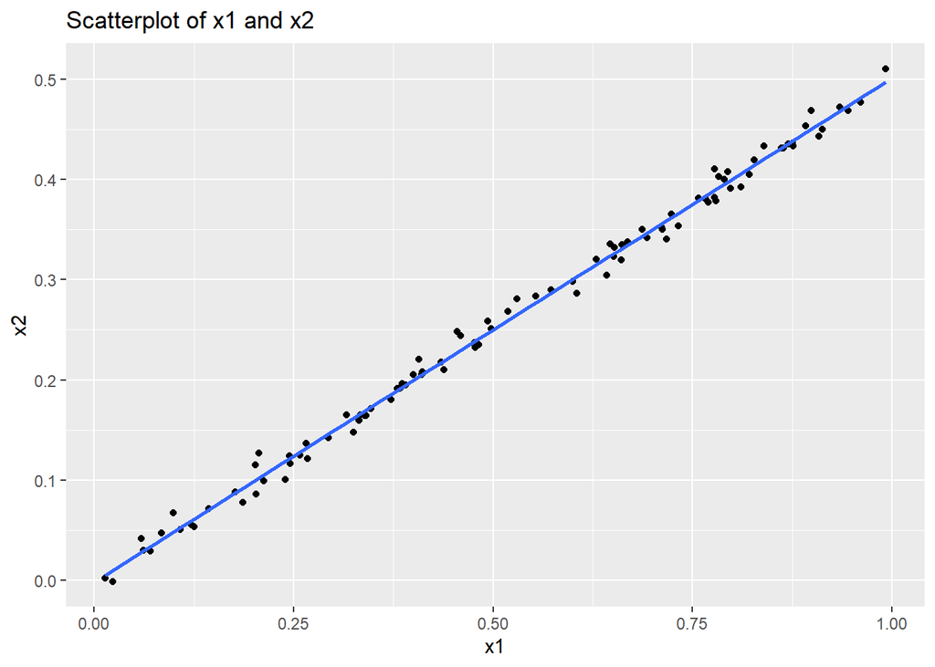

```r
x1x2 = data.frame(x1, x2)
ggplot(data = x1x2, mapping = aes(x = x1, y = x2))+
  geom_point()+
  ggtitle("Scatterplot of x1 and x2") +
  geom_smooth(method = "lm", se = FALSE)
```

As we can see from the scatterplot of x1 and x2 above, we can see a strong, positive, linear relationship between x1 and x2.

**Repeat c:**

```r
model = lm(y ~ x1 + x2)
model
```

```
##
## Call:
## lm(formula = y ~ x1 + x2)
##
## Coefficients:
## (Intercept)           x1           x2
##       2.130       -1.754        7.397
```

From the above code we can know that $\hat{\beta_0}$ = 2.1304996, $\hat{\beta_1}$ = -1.7539783, and $\hat{\beta_2}$ = 7.3967417. They are estimators of $\beta_0$, $\beta_1$ and $\beta_2$.

Since $\hat{\beta_0}$ = 2.1304996, which is similar to $\beta_0=2$, so it is a relative good estimator.

Since $\hat{\beta_1}$ = -1.7539783, which is not similar to $\beta_1=2$, so it is not a relative good estimator.

Since $\hat{\beta_2}$ = 7.3967417, which is not similar to $\beta_2=0.3$, so it is not a relative good estimator.

```r
s = sqrt(sum((model$residuals)^2)/(n-2-1))
s
```

```
## [1] 1.056178
```

From the code above, we can see that $s$ = 1.0561779. Since $\sigma^2$ = 1, which is similar to 1.0561779. So `s` is a relative good estimator of $\sigma^2$.

```r
summary(model)
```

```
##
## Call:
## lm(formula = y ~ x1 + x2)
##
## Residuals:
##     Min      1Q  Median      3Q     Max
## -2.8311 -0.7273 -0.0537  0.6338  2.3359
##
## Coefficients:
##             Estimate Std. Error t value Pr(>|t|)
## (Intercept)   2.1305     0.2319   9.188 7.61e-15 ***
## x1           -1.7540     5.7178  -0.307    0.760
## x2            7.3967    11.3372   0.652    0.516
## ---
## Signif. codes:  0 '***' 0.001 '**' 0.01 '*' 0.05 '.' 0.1 ' ' 1
##
## Residual standard error: 1.056 on 97 degrees of freedom
## Multiple R-squared:  0.2051, Adjusted R-squared:  0.1887
## F-statistic: 12.51 on 2 and 97 DF,  p-value: 1.465e-05
```

Fail to reject $H_0:~\beta_1=0$, p-value is 0.7596855, too large.

Fail to reject $H_0:~\beta_2=0$, p-value is 0.5156672, too large.

**Repeat d:**

```r
model = lm(y ~ x1)
model
```

```
##
## Call:
## lm(formula = y ~ x1)
##
## Coefficients:
## (Intercept)           x1
##       2.117        1.967
```

From the above code we can know that $\hat{\beta_0}$ = 2.1172354 and $\hat{\beta_1}$ = 1.9674957. They are estimators of $\beta_0$ and $\beta_1$.

Since $\hat{\beta_0}$ = 2.1172354, which is similar to $\beta_0=2$, so it is a relative good estimator.

Since $\hat{\beta_1}$ = 1.9674957, which is similar to $\beta_1=2$, so it is a relative good estimator.

```r
s = sqrt(sum((model$residuals)^2)/(n-1-1))
s
```

```
## [1] 1.053078
```

From the code above, we can see that $s$ = 1.0530785. Since $\sigma^2$ = 1, which is similar to 1.0530785. So `s` is a relative good estimator of $\sigma^2$.

```r
summary(model)
```

```
##
## Call:
## lm(formula = y ~ x1)
##
## Residuals:
##      Min       1Q   Median       3Q      Max
## -2.87789 -0.68357 -0.07517  0.61429  2.40388
##
## Coefficients:
##             Estimate Std. Error t value Pr(>|t|)
## (Intercept)   2.1172     0.2303   9.193 6.83e-15 ***
## x1            1.9675     0.3955   4.974 2.79e-06 ***
## ---
## Signif. codes:  0 '***' 0.001 '**' 0.01 '*' 0.05 '.' 0.1 ' ' 1
##
## Residual standard error: 1.053 on 98 degrees of freedom
## Multiple R-squared:  0.2016, Adjusted R-squared:  0.1934
## F-statistic: 24.74 on 1 and 98 DF,  p-value: 2.795e-06
```

Reject $H_0:~\beta_1=0$, p-value is 2.7946175^{-6}, too small.

**Repeat e:**

```r
model = lm(y ~ x2)
model
```

```
##
## Call:
## lm(formula = y ~ x2)
##
## Coefficients:
## (Intercept)           x2
##       2.120        3.927
```

From the above code we can know that $\hat{\beta_0}$ = 2.119906 and $\hat{\beta_2}$ = 3.9273433. They are estimators of $\beta_0$ and $\beta_2$.

Since $\hat{\beta_0}$ = 2.119906, which is similar to $\beta_0=2$, so it is a relative good estimator.

Since $\hat{\beta_2}$ = 3.9273433, which is not similar to $\beta_2=0.3$, so it is not a relative good estimator.

```r
s = sqrt(sum((model$residuals)^2)/(n-1-1))
s
```

```
## [1] 1.051285
```

From the code above, we can see that $s$ = 1.051285. Since $\sigma^2$ = 1, which is similar to 1.051285. So `s` is a relative good estimator of $\sigma^2$.

```r
summary(model)
```

```
##
## Call:
## lm(formula = y ~ x2)
##
## Residuals:
##      Min       1Q   Median       3Q      Max
## -2.85470 -0.68465 -0.06898  0.60983  2.34499
##
## Coefficients:
##             Estimate Std. Error t value Pr(>|t|)
## (Intercept)   2.1199     0.2282   9.288 4.24e-15 ***
## x2            3.9273     0.7829   5.016 2.35e-06 ***
## ---
## Signif. codes:  0 '***' 0.001 '**' 0.01 '*' 0.05 '.' 0.1 ' ' 1
##
## Residual standard error: 1.051 on 98 degrees of freedom
## Multiple R-squared:  0.2043, Adjusted R-squared:  0.1962
## F-statistic: 25.16 on 1 and 98 DF,  p-value: 2.35e-06
```

Reject $H_0:~\beta_2=0$, p-value is 2.3502378^{-6}, too small.

In exercise 1, we got the same result when doing linear regressions `lm(y ~ x1 + x2)`, `lm(y ~ x1)`, and `lm(y ~ x2)`, which is rejecting the null hypotheses: $\beta_1 = 0$ or $\beta_2=0$ or both, which means that $\beta_1$ or $\beta_2$ or both may not be 0.

However, in exercise 2, when doing linear regression `lm(y ~ x1 + x2)`, we fail to reject the null hypotheses, which means $\beta_1$ and $\beta_2$ can be 0.

When we do linear regression `lm(y ~ x1)`, we reject the null hypothesis, which means that $\beta_1$ may not be 0.

When we do linear regression `lm(y ~ x2)`, we reject the null hypothesis, which means that $\beta_2$ may not be 0.

The results are not consistent in exercise 2.

This difference is mainly because of the two datasets have different distributions of data. In exercise 1, the correlation coefficient is about 0.01703215. However, in exercise 2, the correlation coefficient is about 0.9975904.

```r
model = lm(y ~ x1 + x2)
vif(model)
```

```
##       x1       x2
## 207.7504 207.7504
```

We can see from above the collinearity is 207.7504, which is very large. When x1 and x2 are highly correlated, it may have collinearity. In this case, it is difficult to determine x1 and x2 separately with y correctly because collinearity affects the accuracy of $\hat{\beta_1}$ and $\hat{\beta_2}$.

## Problem 3

Use `x1`, `x2` and `y` from Exercise 2 and suppose that we obtain one additional observation, which was unfortunately mismeasured.

```r
x1 <- c(x1, 0.1)
x2 <- c(x2, 0.8)
y <- c(y, 6)
n = 101
cor(x1, x2)
```

```
## [1] 0.8573678
```

**a. (4 pts) Re-fit the linear models from parts c, d and e of Exercise 1 using this new data. What effect does this new observation have on each of the models? In each model, is this observation an outlier? A high-leverage point? Both? Explain your answers.**

**Repeat c:**

```r
model = lm(y ~ x1 + x2)
model
```

```
##
## Call:
## lm(formula = y ~ x1 + x2)
##
## Coefficients:
## (Intercept)           x1           x2
##      2.1250      -0.5183       4.9440
```

From the above code we can know that $\hat{\beta_0}$ = 2.1249533, $\hat{\beta_1}$ = -0.5182774, and $\hat{\beta_2}$ = 4.9440013. They are estimators of $\beta_0$, $\beta_1$ and $\beta_2$.

Since $\hat{\beta_0}$ = 2.1249533, which is similar to $\beta_0=2$, so it is a relative good estimator.

Since $\hat{\beta_1}$ = -0.5182774, which is not similar to $\beta_1=2$, so it is not a relative good estimator.

Since $\hat{\beta_2}$ = 4.9440013, which is not similar to $\beta_2=0.3$, so it is not a relative good estimator.

```r
s = sqrt(sum((model$residuals)^2)/(n-2-1))
s
```

```
## [1] 1.051033
```

From the code above, we can see that $s$ = 1.0510329. Since $\sigma^2$ = 1, which is similar to 1.0510329. So `s` is a relative good estimator of $\sigma^2$.

```r
summary(model)
```

```
##
## Call:
## lm(formula = y ~ x1 + x2)
##
## Residuals:
##      Min       1Q   Median       3Q      Max
## -2.84668 -0.67731 -0.05031  0.58942  2.34440
##
## Coefficients:
##             Estimate Std. Error t value Pr(>|t|)
## (Intercept)   2.1250     0.2294   9.265 4.77e-15 ***
## x1           -0.5183     0.7578  -0.684 0.495630
## x2            4.9440     1.4114   3.503 0.000695 ***
## ---
## Signif. codes:  0 '***' 0.001 '**' 0.01 '*' 0.05 '.' 0.1 ' ' 1
##
## Residual standard error: 1.051 on 98 degrees of freedom
## Multiple R-squared:  0.2495, Adjusted R-squared:  0.2341
## F-statistic: 16.29 on 2 and 98 DF,  p-value: 7.82e-07
```

Fail to reject $H_0:~\beta_1=0$, p-value is 0.4956304, too large.

Reject $H_0:~\beta_2=0$, p-value is 6.9528685^{-4}, too small.

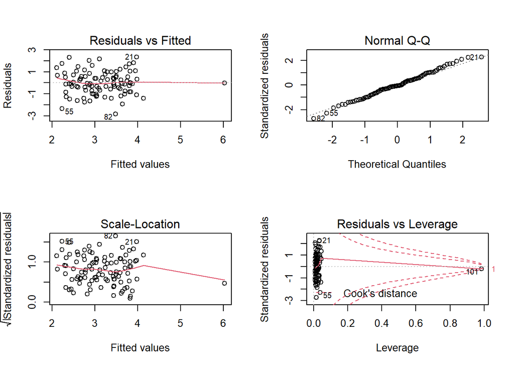

```r
par(mfrow = c(2, 2))
plot(lm(y ~ x1 + x2))
```

```r
#check outliers
head(rstandard(model)[rstandard(model) < -3 | rstandard(model) > 3])
```

```
## named numeric(0)
```

```r
#check leverage
head(hatvalues(model)[hatvalues(model) > (2+1)/(n)])
```

```
##          4          6          7         10         18         21
## 0.03134825 0.03167553 0.03554767 0.03929726 0.04264765 0.03467333
```

From the Residuals vs Leverage plot and the calculation above, we can see that we have high leverage, but no outlier.

**Repeat d:**

```r
model = lm(y ~ x1)
model
```

```
##
## Call:
## lm(formula = y ~ x1)
##
## Coefficients:
## (Intercept)           x1
##       2.262        1.757
```

From the above code we can know that $\hat{\beta_0}$ = 2.2616126 and $\hat{\beta_1}$ = 1.75749. They are estimators of $\beta_0$ and $\beta_1$.

Since $\hat{\beta_0}$ = 2.2616126, which is not similar to $\beta_0=2$, so it is not a relative good estimator.

Since $\hat{\beta_1}$ = 1.75749, which is not similar to $\beta_1=2$, so it is not a relative good estimator.

```r
s = sqrt(sum((model$residuals)^2)/(n-1-1))
s
```

```
## [1] 1.109242
```

From the code above, we can see that $s$ = 1.1092422. Since $\sigma^2$ = 1, which is not similar to 1.1092422. So `s` is not a relative good estimator of $\sigma^2$.

```r
summary(model)
```

```
##
## Call:
## lm(formula = y ~ x1)
##
## Residuals:
##     Min      1Q  Median      3Q     Max
## -2.8726 -0.6826 -0.0747  0.5774  3.5626
##
## Coefficients:
##             Estimate Std. Error t value Pr(>|t|)
## (Intercept)   2.2616     0.2385   9.481 1.48e-15 ***
## x1            1.7575     0.4116   4.270 4.50e-05 ***
## ---
## Signif. codes:  0 '***' 0.001 '**' 0.01 '*' 0.05 '.' 0.1 ' ' 1
##
## Residual standard error: 1.109 on 99 degrees of freedom
## Multiple R-squared:  0.1555, Adjusted R-squared:  0.147
## F-statistic: 18.23 on 1 and 99 DF,  p-value: 4.498e-05
```

Reject $H_0:~\beta_1=0$, p-value is 4.4984622^{-5}, too small.

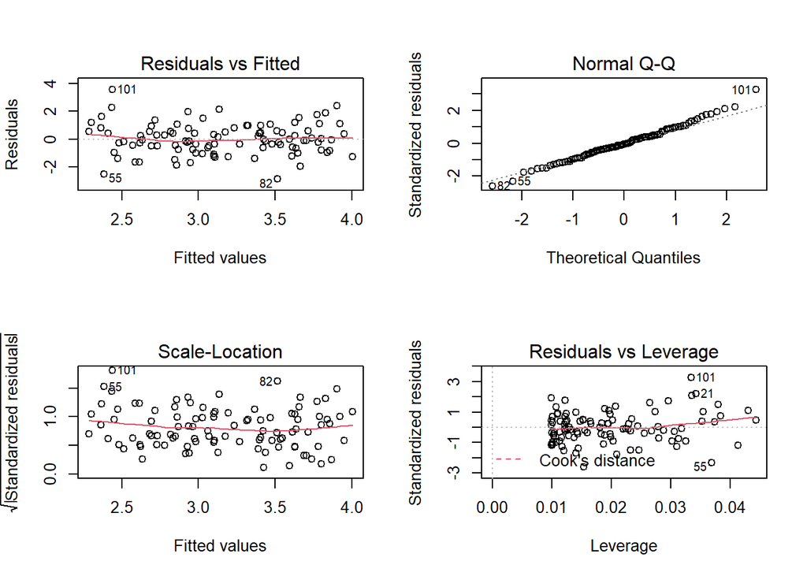

```r
par(mfrow = c(2, 2))
plot(lm(y ~ x1))
```

```r
#check outliers
head(rstandard(model)[rstandard(model) < -3 | rstandard(model) > 3])
```

```
##      101
## 3.266916
```

```r
#check leverage
head(hatvalues(model)[hatvalues(model) > (1+1)/(n)])
```

```
##          4          5          6          7         10         11
## 0.03133322 0.02330903 0.03027970 0.03547876 0.03802701 0.02294265
```

From the Residuals vs Leverage plot and the calculation, we can see that we have outlier, and we have high leverage.

**Repeat e:**

```r
model = lm(y ~ x2)
model
```

```
##
## Call:
## lm(formula = y ~ x2)
##
## Coefficients:
## (Intercept)           x2
##       2.077        4.116
```

From the above code we can know that $\hat{\beta_0}$ = 2.0772972 and $\hat{\beta_2}$ = 4.1163502. They are estimators of $\beta_0$ and $\beta_2$.

Since $\hat{\beta_0}$ = 2.0772972, which is similar to $\beta_0=2$, so it is a relative good estimator.

Since $\hat{\beta_1}$ = 4.1163502, which is not similar to $\beta_3=0.3$, so it is not a relative good estimator

```r
s = sqrt(sum((model$residuals)^2)/(n-1-1))
s
```

```
## [1] 1.048204
```

From the code above, we can see that $s$ = 1.0482039. Since $\sigma^2$ = 1, which is similar to 1.0482039. So `s` is a relative good estimator of $\sigma^2$.

```r
summary(model)
```

```
##
## Call:
## lm(formula = y ~ x2)
##
## Residuals:
##      Min       1Q   Median       3Q      Max
## -2.87832 -0.66757 -0.06731  0.62962  2.36205
##
## Coefficients:
##             Estimate Std. Error t value Pr(>|t|)
## (Intercept)   2.0773     0.2179   9.532 1.15e-15 ***
## x2            4.1164     0.7245   5.681 1.34e-07 ***
## ---
## Signif. codes:  0 '***' 0.001 '**' 0.01 '*' 0.05 '.' 0.1 ' ' 1
##
## Residual standard error: 1.048 on 99 degrees of freedom
## Multiple R-squared:  0.2459, Adjusted R-squared:  0.2383
## F-statistic: 32.28 on 1 and 99 DF,  p-value: 1.345e-07
```

Reject $H_0:~\beta_2=0$, p-value is 1.3446913^{-7}, too small.

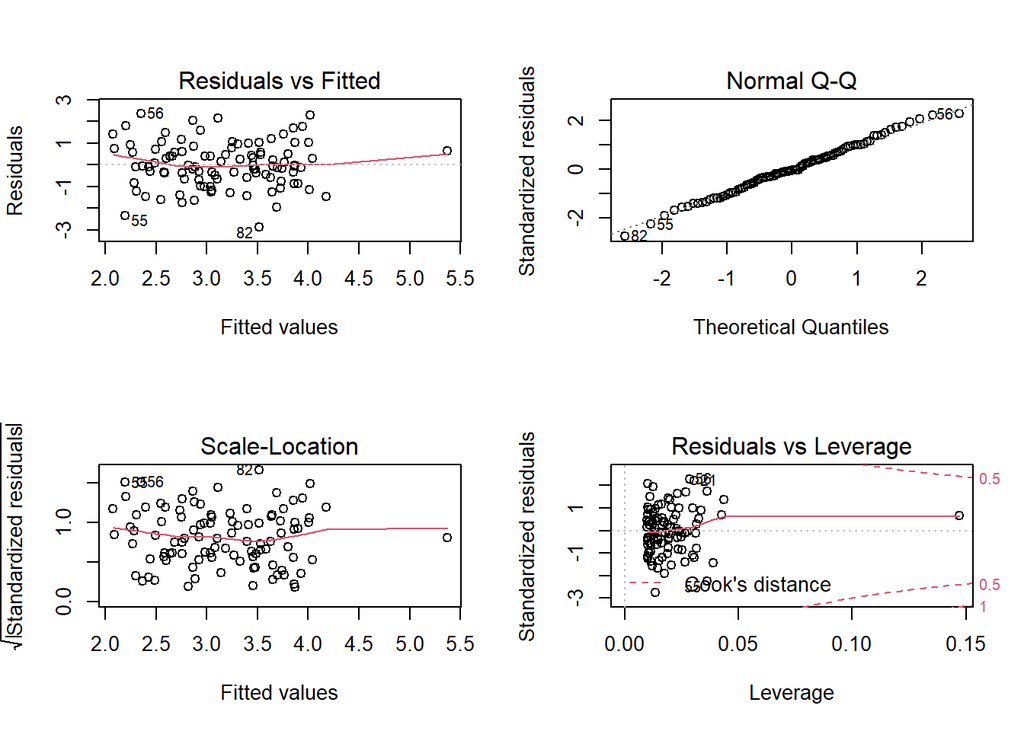

```r
par(mfrow = c(2, 2))
plot(lm(y ~ x2))
```

```r
#check outliers
head(rstandard(model)[rstandard(model) < -3 | rstandard(model) > 3])
```

```
## named numeric(0)
```

```r
#check leverage
head(hatvalues(model)[hatvalues(model) > (1+1)/(n)])
```

```
##          4          5          6          7         10         12
## 0.02515838 0.02049865 0.02995792 0.02989270 0.03618774 0.02473736
```

From the Residuals vs Leverage plot, we can see that we don’t have outlier, but we have high leverage.

When we fit linear regression `lm(y ~ x1 + x2)` we fail to reject $H_0:~\beta_1=0$ and conclude $\beta_1$ may be 0, and we reject $H_0:~\beta_2=0$ and conclude $\beta_2$ may not be 0.

However, when we fit linear regression `lm(y ~ x2)`, we reject $H_0:~\beta_1=0$ and conclude $\beta_1$ may not be 0.

The results are not consistent.

# II. Multiple Linear Regression: Application

Load the `Carseats` data set contained in the `ISLR` library. `Carseats` is a simulated data set containing sales of child car seats at 400 different stores.

It contains the following variables:

- `Sales`: Unit sales (in thousands) at each location
- `CompPrice`: Price charged by competitor at each location
- `Income`: Community income level (in thousands of dollars)
- `Advertising`: Local advertising budget for company at each location (in thousands of dollars)
- `Population`: Population size in region (in thousands)
- `Price`: Price company charges for car seats at each site
- `ShelveLoc`: A factor with levels Bad, Good and Medium indicating the quality of the shelving location for the car seats at each site
- `Age`: Average age of the local population
- `Education`: Education level at each location
- `Urban`: A factor with levels No and Yes to indicate whether the store is in an urban or rural location
- `US`: A factor with levels No and Yes to indicate whether the store is in the US or not

For this Problem you will consider only Sales, Price, Income, Urban, ShelveLoc and Advertising.

## Problem a

(2 points) Graphically explore the relationship between the six above variables (use the `ggpairs` function in the `GGally`). Comment on the plots: are they bivariate or univariate plots? Describe the plots (x-axis, y-axis, etc). What do you notice in the distribution of the variable `advertising`?

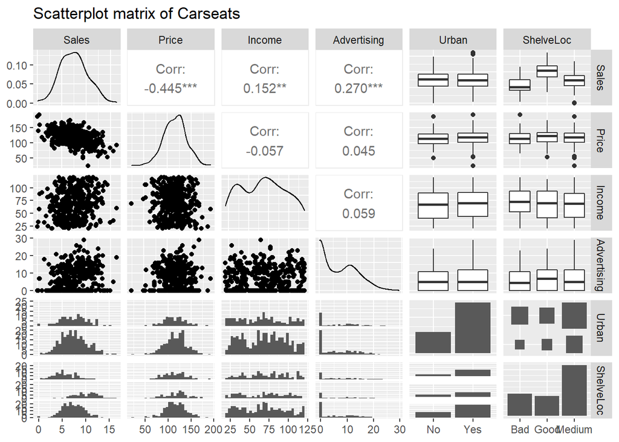

```r
rm(list=ls())
library(ISLR)
ggpairs(Carseats[, c(1,6,3,4,10,7)],
        title = "Scatterplot matrix of Carseats")
```

All plots on the diagonal are `univariate` since they take one variable.

All plots other than the diagonal are `bivariate` since they take two variables.

The x-axis represents the variables of the columns, and the y-axis represents the variables of the rows.

## Problem b

(2 points) Fit a multiple regression model to predict Sales using Price, Income, Urban, Advertsing, and ShelveLoc. Provide an interpretation of each coefficient in the model (be careful—some of the variables in the model are qualitative!).

```r
model = lm(Sales ~ Price + Income + Urban + Advertising + ShelveLoc, data = Carseats)
model
```

```
##
## Call:
## lm(formula = Sales ~ Price + Income + Urban + Advertising + ShelveLoc,
##     data = Carseats)
##
## Coefficients:
##     (Intercept)            Price           Income         UrbanYes
##        10.27293         -0.05724          0.01364          0.19689
##     Advertising    ShelveLocGood  ShelveLocMedium
##         0.10506          4.85654          1.91184
```

When the price increase by 1 unit, the sales will decrease 0.05724 on average, given other variables are fixed.

When the income increase by 1 unit, the sales will increase 0.01364 on average, given other variables are fixed.

When the urban (yes) increase by 1 unit, the sales will increase 0.19689 on average, given other variables are fixed.

When the advertising increase by 1 unit, the sales will increase 0.10506 on average, given other variables are fixed.

When the ShelveLoc (Good) increase by 1 unit, the sales will increase 4.85654 on average, given other variables are fixed.

When the ShelveLoc (Medium) increase by 1 unit, the sales will increase 1.91184 on average, given other variables are fixed.

## Problem c

(1 point) Write out the model in equation form, being careful to handle the qualitative variables properly (check this out: https://rmd4sci.njtierney.com/math to learn how to insert equations in Rmarkdown).

$$Y=10.27293-0.05724X_{Price}+0.01364X_{Income}+0.19689X_{UrbanYes}+0.10506X_{Advertising}+4.85654X_{ShelveLocGood}$$
$$+1.91184X_{ShelveLocMedium}+\epsilon,~where~X_{UrbanYes}\in\{0,1\}~and~X_{ShelveLocGood},X_{ShelveLocMedium}\in\{0,1\}$$

## Problem d

(2 points) For which of the predictors can you reject the null hypothesis $H_0:~\beta_j=0$? Moreover, which are the most significant variables?

```r
summary(model)
```

```
##
## Call:
## lm(formula = Sales ~ Price + Income + Urban + Advertising + ShelveLoc,
##     data = Carseats)
##
## Residuals:
##     Min      1Q  Median      3Q     Max
## -5.1957 -1.1420  0.0375  1.0624  4.1492
##
## Coefficients:
##                  Estimate Std. Error t value Pr(>|t|)
## (Intercept)     10.272928   0.533930  19.240  < 2e-16 ***
## Price           -0.057238   0.003690 -15.513  < 2e-16 ***
## Income           0.013643   0.003126   4.364 1.64e-05 ***
## UrbanYes         0.196891   0.191522   1.028    0.305
## Advertising      0.105056   0.013141   7.994 1.47e-14 ***
## ShelveLocGood    4.856543   0.260412  18.649  < 2e-16 ***
## ShelveLocMedium  1.911844   0.213703   8.946  < 2e-16 ***
## ---
## Signif. codes:  0 '***' 0.001 '**' 0.01 '*' 0.05 '.' 0.1 ' ' 1
##
## Residual standard error: 1.736 on 393 degrees of freedom
## Multiple R-squared:  0.6278, Adjusted R-squared:  0.6221
## F-statistic: 110.5 on 6 and 393 DF,  p-value: < 2.2e-16
```

```r
summary(model)$coefficient[,4]
```

```
##     (Intercept)           Price          Income        UrbanYes     Advertising
##    1.323306e-58    1.110980e-42    1.636201e-05    3.045649e-01    1.466464e-14
##   ShelveLocGood ShelveLocMedium
##    4.667068e-56    1.467440e-17
```

We can reject $H_0:~\beta_j=0$ on price, income, advertising, ShelveLoc (Good), and ShelveLoc (Medium). However, we fail to reject $H_0:~\beta_j=0$ on Urban (Yes).

The most significant variable is `ShelveLocGood` since its p-value is 4.6670683^{-56}, which is the smallest, and its t-statistic is 18.649, which is the largest.

## Problem e

(2 point) On the basis of your response to the previous question, fit a smaller model that only uses the predictors for which there is evidence of association with the outcome. Use the `anova()` function to compare the models and comment on the results.

```r
model = lm(Sales ~ Price + Income + Advertising + ShelveLoc, data = Carseats)
model
```

```
##
## Call:
## lm(formula = Sales ~ Price + Income + Advertising + ShelveLoc,
##     data = Carseats)
##
## Coefficients:
##     (Intercept)            Price           Income      Advertising
##        10.39160         -0.05705          0.01375          0.10562
##   ShelveLocGood  ShelveLocMedium
##         4.83592          1.89590
```

```r
anova(model)
```

|  | Df | Sum Sq | Mean Sq | F value | Pr(>F) |
| --- | --- | --- | --- | --- | --- |
| Price | 1 | 630.03040 | 630.030405 | 209.02375 | 2.623119e-38 |
| Income | 1 | 51.26812 | 51.268124 | 17.00911 | 4.539911e-05 |
| Advertising | 1 | 253.64100 | 253.641003 | 84.14990 | 2.599047e-18 |
| ShelveLoc | 2 | 1059.75730 | 529.878650 | 175.79663 | 2.690709e-55 |
| Residuals | 394 | 1187.57787 | 3.014157 | NA | NA |

From the ANOVA result, we may conclude that all those 4 significant variables, price, income, advertising, and ShelveLoc have effect on the sales because their p-values are too small, which lead us reject their null hypotheses (they have no effect on sales).

## Problem f

(3 points) Consider the reduced model in (e). Test whether the errors are correlated. Moreover, plot and test the residuals to see whether there is heteroskedasticity, whether the normality assumption holds. Use the residual plots to discuss whether there is evidence of outliers or high leverage observations.

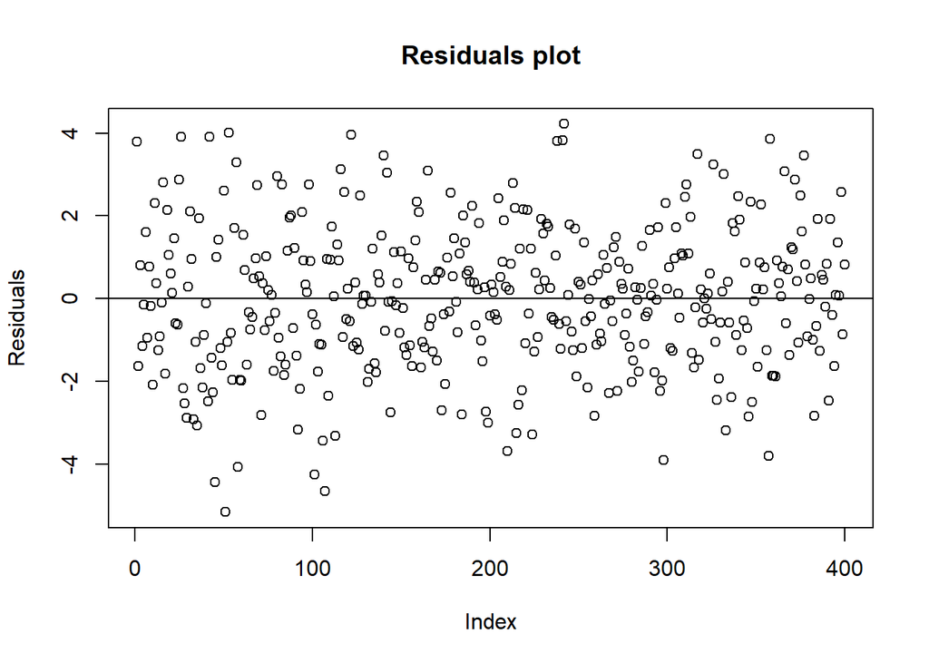

```r
plot(model$residuals, ylab = "Residuals", xlab = "Index",
     main = "Residuals plot")
abline(0, 0)
```

```r
Box.test(model$residuals)
```

```
##
##  Box-Pierce test
##
## data:  model$residuals
## X-squared = 0.16243, df = 1, p-value = 0.6869
```

```r
dwt(model)
```

```
##  lag Autocorrelation D-W Statistic p-value
##    1     -0.02015137      2.027652   0.762
##  Alternative hypothesis: rho != 0
```

```r
bptest(model)
```

```
##
##  studentized Breusch-Pagan test
##
## data:  model
## BP = 1.9009, df = 5, p-value = 0.8627
```

From the Breusch-Pagan test, since the p-value is 0.8627, we can conclude that the residuals have homoskedasticity.

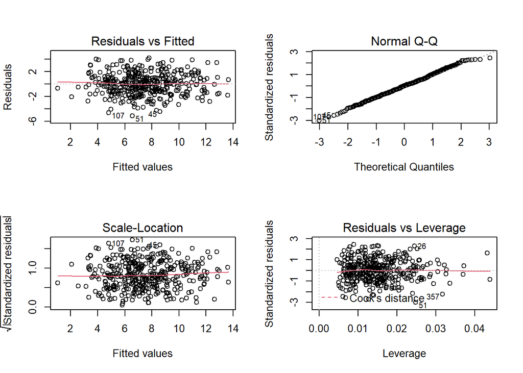

```r
par(mfrow = c(2, 2))
plot(model)
```

```r
#check outliers
head(rstandard(model)[rstandard(model) < -3 | rstandard(model) > 3])
```

```
##        51
## -3.004912
```

```r
#check leverage
head(hatvalues(model)[hatvalues(model) > (4+1)/400])
```

```
##          2          3          6          8          9         10
## 0.02385900 0.01524786 0.02566011 0.01549497 0.01393795 0.01484117
```

Moreover, from the residuals vs leverage plot and calculation above, we can see we have an outlier, and we have high leverage observations.

From the Normal Q-Q plot, since almost all the points fit the dash line, we can conclude that the residuals have normaility.

## Problem g

(2 points) Consider the variable `Advertising`. Create a variable called `Advertising_levels` which is equal to `None` if Advertising=0, `Low` if `Advertising` is less than 10, `Medium` if `Advertising` is between 10 and 20, and `High` otherwise. Fit the reduced model in (e) including the variable `Advertising_levels` instead of the variable `Advertsing`. Interpret the coefficients of the variable `Advertising_levels` and compare it with the coefficient of `Advertising` given by the model in (e).

```r
df = as.data.frame(Carseats)
df$Advertising_levels[df$Advertising==0] = "None"
df$Advertising_levels[df$Advertising<=10&df$Advertising!=0] = "Low"
df$Advertising_levels[df$Advertising>10&df$Advertising<=20] = "Medium"
df$Advertising_levels[df$Advertising>20] = "High"
model = lm(Sales ~ Price + Income + Advertising_levels + ShelveLoc, data = df)
model
```

```
##
## Call:
## lm(formula = Sales ~ Price + Income + Advertising_levels + ShelveLoc,
##     data = df)
##
## Coefficients:
##              (Intercept)                     Price                    Income
##                 13.49887                  -0.05810                   0.01366
##    Advertising_levelsLow  Advertising_levelsMedium    Advertising_levelsNone
##                 -2.25995                  -1.64625                  -3.03290
##            ShelveLocGood           ShelveLocMedium
##                  4.90148                   1.92623
```

When the Advertising levels (Low) increase by 1 unit, the sales will decrease 2.2599509 on average, given other variables are fixed.

When the Advertising levels (Medium) increase by 1 unit, the sales will decrease 1.6462465 on average, given other variables are fixed.

When the Advertising levels (None) increase by 1 unit, the sales will decrease 3.0328953 on average, given other variables are fixed.

In problem e, when the Advertising increase by 1 unit, the sales will increase 0.10562 on average, given other variables are fixed.

The coefficient of Advertising we got in problem e is 0.10562. However, the coefficients we got in this problem, we got Advertising levels (Low) coefficient is -2.2599509, Advertising levels (Medium) coefficient is -1.6462465, Advertising levels (None) coefficient is -3.0328953.

It is possible that when the advertising level is high, sales will increase.

# Appendix: R Script

```r
knitr::opts_chunk$set(echo = TRUE)
rm(list = ls())
library(ggplot2)
library(GGally)
library(car)
library(lmtest)
library(knitr)
set.seed(1)
n <- 100
x1 <- runif(n)
x2 <- runif(n,10,20)
y <- 2+2*x1+0.3*x2+rnorm(n)
correlation = cor(x1, x2)
correlation
x1x2 = data.frame(x1, x2)
ggplot(data = x1x2, mapping = aes(x = x1, y = x2))+
  geom_point()+
  ggtitle("Scatterplot of x1 and x2") +
  geom_smooth(method = "lm", se = FALSE)
model = lm(y ~ x1 + x2)
model
s = sqrt(sum((model$residuals)^2)/(n-2-1))
s
summary(model)
model = lm(y ~ x1)
model
s = sqrt(sum((model$residuals)^2)/(n-1-1))
s
summary(model)
model = lm(y ~ x2)
model
s = sqrt(sum((model$residuals)^2)/(n-1-1))
s
summary(model)
rm(list=ls())
set.seed(1)
n <- 100
x1 <- runif(n)
x2 <- 0.5*x1+rnorm(n,0,.01)
y <- 2+2*x1+0.3*x2+rnorm(n)
correlation = cor(x1, x2)
correlation
x1x2 = data.frame(x1, x2)
ggplot(data = x1x2, mapping = aes(x = x1, y = x2))+
  geom_point()+
  ggtitle("Scatterplot of x1 and x2") +
  geom_smooth(method = "lm", se = FALSE)
model = lm(y ~ x1 + x2)
model
s = sqrt(sum((model$residuals)^2)/(n-2-1))
s
summary(model)
model = lm(y ~ x1)
model
s = sqrt(sum((model$residuals)^2)/(n-1-1))
s
summary(model)
model = lm(y ~ x2)
model
s = sqrt(sum((model$residuals)^2)/(n-1-1))
s
summary(model)
model = lm(y ~ x1 + x2)
vif(model)
x1 <- c(x1, 0.1)
x2 <- c(x2, 0.8)
y <- c(y, 6)
n = 101
cor(x1, x2)
model = lm(y ~ x1 + x2)
model
s = sqrt(sum((model$residuals)^2)/(n-2-1))
s
summary(model)
par(mfrow = c(2, 2))
plot(lm(y ~ x1 + x2))
#check outliers
head(rstandard(model)[rstandard(model) < -3 | rstandard(model) > 3])
#check leverage
head(hatvalues(model)[hatvalues(model) > (2+1)/(n)])
model = lm(y ~ x1)
model
s = sqrt(sum((model$residuals)^2)/(n-1-1))
s
summary(model)
par(mfrow = c(2, 2))
plot(lm(y ~ x1))
#check outliers
head(rstandard(model)[rstandard(model) < -3 | rstandard(model) > 3])
#check leverage
head(hatvalues(model)[hatvalues(model) > (1+1)/(n)])
model = lm(y ~ x2)
model
s = sqrt(sum((model$residuals)^2)/(n-1-1))
s
summary(model)
par(mfrow = c(2, 2))
plot(lm(y ~ x2))
#check outliers
head(rstandard(model)[rstandard(model) < -3 | rstandard(model) > 3])
#check leverage
head(hatvalues(model)[hatvalues(model) > (1+1)/(n)])
rm(list=ls())
library(ISLR)
ggpairs(Carseats[, c(1,6,3,4,10,7)],
        title = "Scatterplot matrix of Carseats")
model = lm(Sales ~ Price + Income + Urban + Advertising + ShelveLoc, data = Carseats)
model
summary(model)
summary(model)$coefficient[,4]
model = lm(Sales ~ Price + Income + Advertising + ShelveLoc, data = Carseats)
model
anova(model)
plot(model$residuals, ylab = "Residuals", xlab = "Index",
     main = "Residuals plot")
abline(0, 0)
Box.test(model$residuals)
dwt(model)
bptest(model)
par(mfrow = c(2, 2))
plot(model)
#check outliers
head(rstandard(model)[rstandard(model) < -3 | rstandard(model) > 3])
#check leverage
head(hatvalues(model)[hatvalues(model) > (4+1)/400])
df = as.data.frame(Carseats)
df$Advertising_levels[df$Advertising==0] = "None"
df$Advertising_levels[df$Advertising<=10&df$Advertising!=0] = "Low"
df$Advertising_levels[df$Advertising>10&df$Advertising<=20] = "Medium"
df$Advertising_levels[df$Advertising>20] = "High"
model = lm(Sales ~ Price + Income + Advertising_levels + ShelveLoc, data = df)
model
```